# Praktikum 6

Latihan

Nabila Nur Faizah (M0401241048)

24 September 2026

# Packages

```r
library(ggplot2)
library(tsibble)
library(tseries)
library(MASS)
library(forecast)
library(TSA)
library(TTR)
library(aTSA)
library(graphics)
library(readxl)
library(rio)
```

# Data

```r
data<- import("https://raw.githubusercontent.com/nabilaanf/mpdw/refs/heads/main/Pertemuan%201/Gugus%20Data%20yang%20Dipakai_XAU_IDR%20Historical%20Data.xlsx")

data$Date<-as.Date(data$Date, format="%m/%d/%Y")
data<-data[order(data$Date),]
data.ts<-ts(data[,3])
data.ts
```

```
## Time Series:
## Start = 1
## End = 209
## Frequency = 1
##   [1] 1213.07 1238.55 1229.90 1236.70 1249.38 1214.03 1210.40 1202.33 1213.27
##  [10] 1217.79 1220.08 1194.54 1207.28 1219.32 1229.16 1216.14 1238.37 1245.64
##  [19] 1244.58 1222.62 1197.24 1199.70 1213.78 1221.18 1214.09 1225.43 1215.31
##  [28] 1204.55 1229.50 1221.69 1227.64 1223.61 1246.25 1227.51 1229.31 1220.58
##  [37] 1210.86 1226.93 1224.51 1258.82 1283.83 1271.74 1269.64 1249.27 1249.29
##  [46] 1254.77 1249.05 1234.76 1249.67 1247.39 1261.69 1278.60 1254.44 1233.40
##  [55] 1239.33 1264.54 1251.56 1246.55 1249.68 1245.22 1250.68 1248.68 1256.66
##  [64] 1241.56 1249.11 1243.33 1275.85 1277.59 1266.29 1261.11 1266.42 1276.69
##  [73] 1283.52 1296.58 1289.43 1302.42 1292.09 1281.88 1324.53 1332.69 1331.79
##  [82] 1340.97 1354.08 1374.58 1362.66 1369.51 1381.20 1385.85 1405.36 1406.00
##  [91] 1384.11 1304.30 1306.53 1305.17 1330.20 1339.07 1351.48 1364.95 1384.05
## [100] 1337.64 1348.14 1350.54 1347.08 1351.37 1361.65 1363.88 1366.30 1336.83
## [109] 1358.00 1364.17 1357.91 1359.80 1359.80 1369.87 1367.13 1351.67 1357.31
## [118] 1392.19 1399.54 1414.50 1427.28 1399.23 1389.74 1385.37 1373.20 1372.26
## [127] 1373.29 1383.30 1357.31 1371.84 1389.41 1372.80 1355.96 1341.28 1341.09
## [136] 1356.60 1354.12 1348.00 1317.65 1319.21 1351.66 1368.24 1352.65 1387.60
## [145] 1385.12 1382.36 1352.56 1329.98 1323.30 1309.16 1318.19 1331.54 1320.50
## [154] 1316.04 1303.90 1300.58 1268.83 1243.17 1249.10 1244.30 1233.12 1245.58
## [163] 1240.96 1243.36 1247.09 1266.51 1244.24 1240.02 1228.08 1241.95 1254.12
## [172] 1272.20 1275.70 1250.79 1257.04 1237.59 1234.61 1232.30 1251.34 1236.64
## [181] 1239.48 1227.42 1223.33 1216.56 1213.02 1208.67 1193.43 1241.65 1231.97
## [190] 1212.52 1225.67 1217.12 1209.97 1190.13 1193.39 1196.79 1190.37 1197.86
## [199] 1212.01 1193.31 1207.98 1188.20 1198.10 1191.04 1186.29 1169.94 1176.33
## [208] 1165.16 1149.92
```

# Eksplorasi Data

## Plot Data Penuh

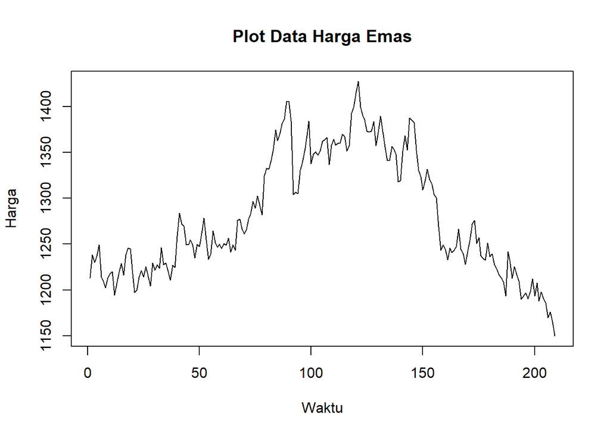

```r
plot.ts(data.ts,
        lty = 1,
        xlab = "Waktu",
        ylab = "Harga",
        main = "Plot Data Harga Emas")
```

## Plot Data Latih

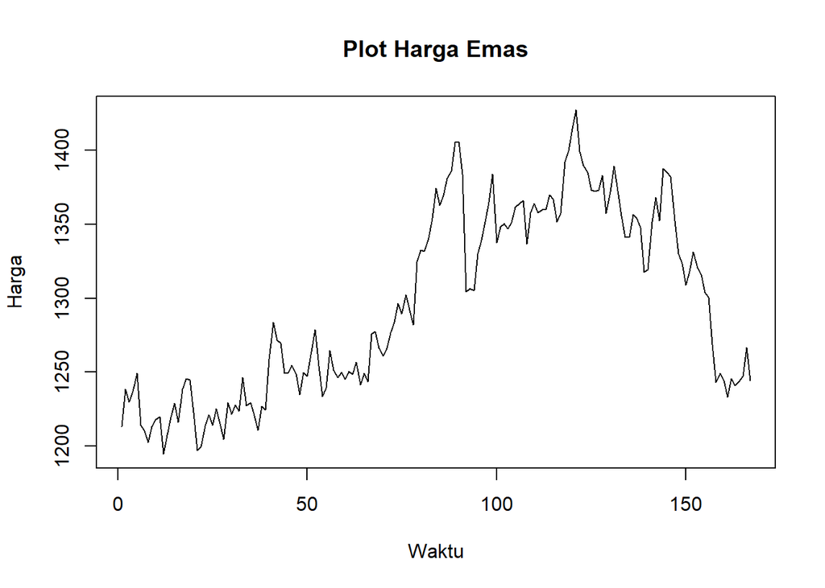

```r
train.ts<-data.ts[1:167]
plot.ts(train.ts, lty=1, xlab="Waktu", ylab="Harga", main="Plot Harga Emas")
```

## Plot Data Uji

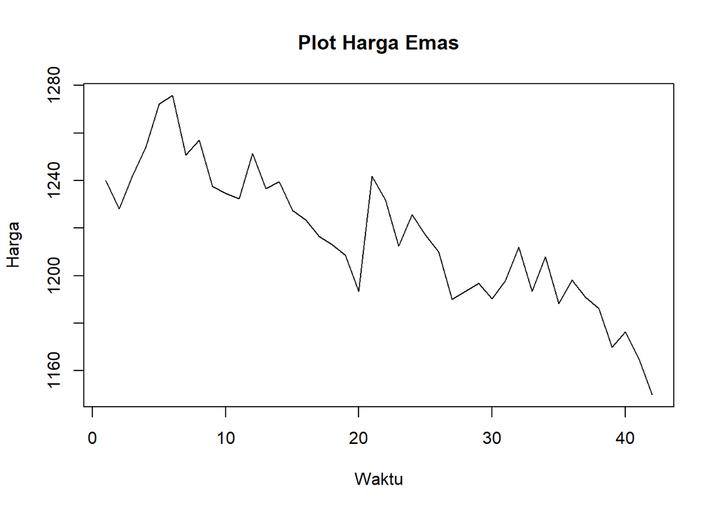

```r
test.ts<-data.ts[168:209]
plot.ts(test.ts, lty=1, xlab="Waktu", ylab="Harga", main="Plot Harga Emas")
```

# Uji Stasioneritas Data

## Plot ACF

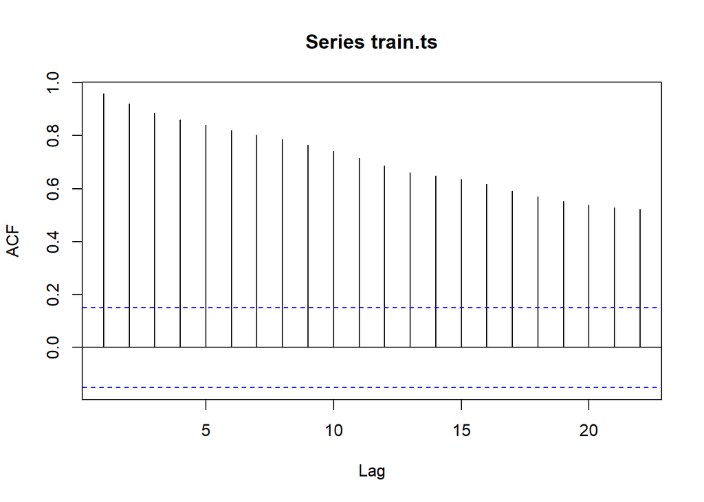

```r
acf(train.ts)
```

Terlihat bahwa plot ACF menurun secara perlahan (*tails of slowly*). Hal ini menjadi indikasi bahwa data tidak stasioner dalam rataan.

## Plot ADF

```r
tseries::adf.test(train.ts)
```

```
##
##  Augmented Dickey-Fuller Test
##
## data:  train.ts
## Dickey-Fuller = -0.33741, Lag order = 5, p-value = 0.988
## alternative hypothesis: stationary
```

$H_0$ : Data tidak stasioner dalam rataan

$H_1$ : Data stasioner dalam rataan

Berdasarkan uji ADF, didapat *p-value* sebesar 0.988 yang lebih besar dari taraf nyata 5%, maka tak tolak $H_0$. Hal ini berarti data tidak stasioner dalam rataan dan sesuai dengan hasil eksplorasi menggunakan plot time series dan plot ACF, sehingga ketidakstasioneran model kedepannya harus ditangani.

## Plot Box-Cox

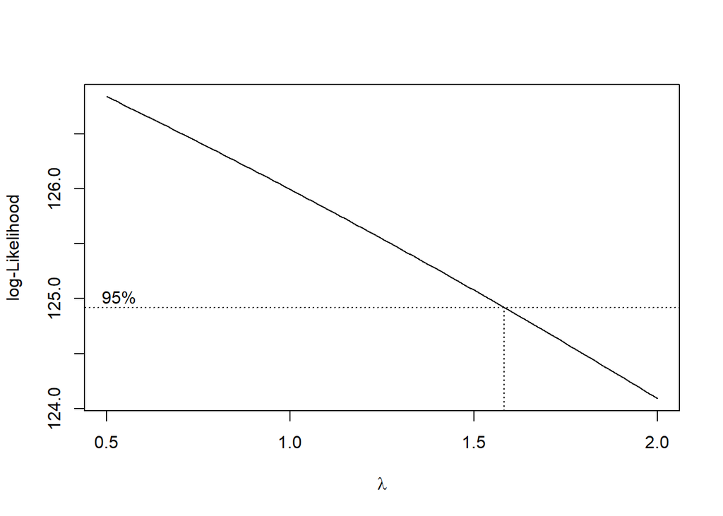

```r
index <- seq(1:167)

bc <- boxcox(train.ts ~ index, lambda = seq(0.5, 2, by = 0.1))
```

```r
lambda_opt <- bc$x[which.max(bc$y)]
lambda_opt
```

```
## [1] 0.5
```

```r
ci_lambda <- bc$x[bc$y > max(bc$y) - 0.5 * qchisq(0.95, df = 1)]

ci_lower <- min(ci_lambda)
ci_upper <- max(ci_lambda)

c(Batas_Bawah = ci_lower, Batas_Atas = ci_upper)
```

```
## Batas_Bawah  Batas_Atas
##    0.500000    1.575758
```

Uji Box‑Cox menghasilkan estimasi optimum $\hat{\lambda}$= 0.5 dengan interval kepercayaan 95% sebesar [0.50; 1.58]. Karena nilai 1 (skala asli) termuat di dalam interval tersebut, transformasi Box‑Cox tidak diperlukan dan pemodelan dilanjutkan pada skala asli.

# Penanganan Ketidakstasioneran Data

## Differencing

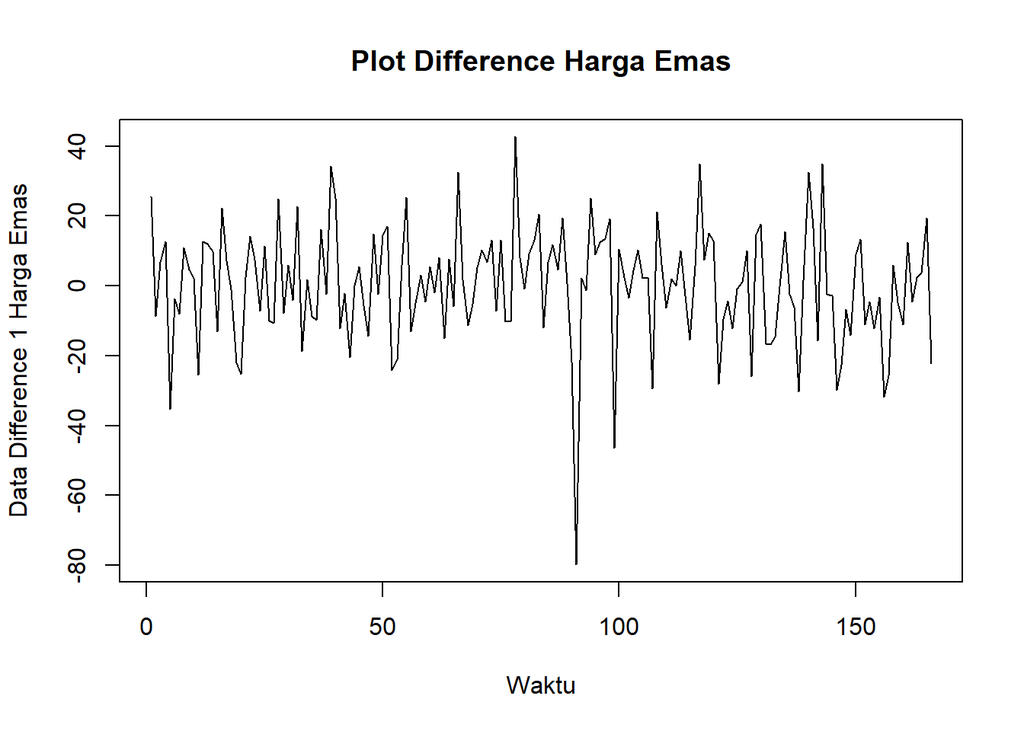

```r
train.diff<-diff(train.ts,differences = 1)

plot.ts(train.diff, lty=1, xlab="Waktu", ylab="Data Difference 1 Harga Emas", main="Plot Difference Harga Emas")
```

Berdasarkan plot data deret waktu, terlihat data sudah stasioner dalam rataan yang ditandai dengan data bergerak pada nilai tengah tertentu (tidak terdapat trend ataupun musiman pada data).

## Plot ACF

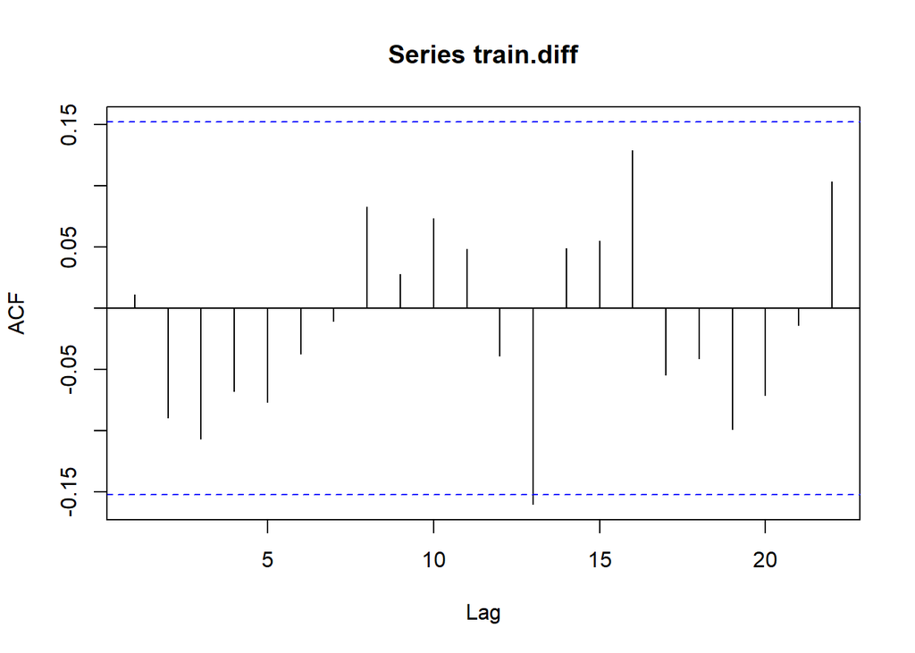

```r
acf(train.diff)
```

## Uji ADF

```r
tseries::adf.test(train.diff)
```

```
##
##  Augmented Dickey-Fuller Test
##
## data:  train.diff
## Dickey-Fuller = -6.789, Lag order = 5, p-value = 0.01
## alternative hypothesis: stationary
```

Differencing orde satu menghasilkan deret $\Delta Y_t$ yang secara visual berpusat di sekitar nol tanpa tren, dengan ACF yang turun cepat. Uji ADF pada $\Delta Y_t$ memberikan DF = −6.789 dengan p‑value = 0.01, sehingga hipotesis nol ditolak dan deret differencing dinyatakan stasioner. Orde differencing d = 1 ditetapkan sebagai cukup.

# Identifikasi Model

## Plot ACF

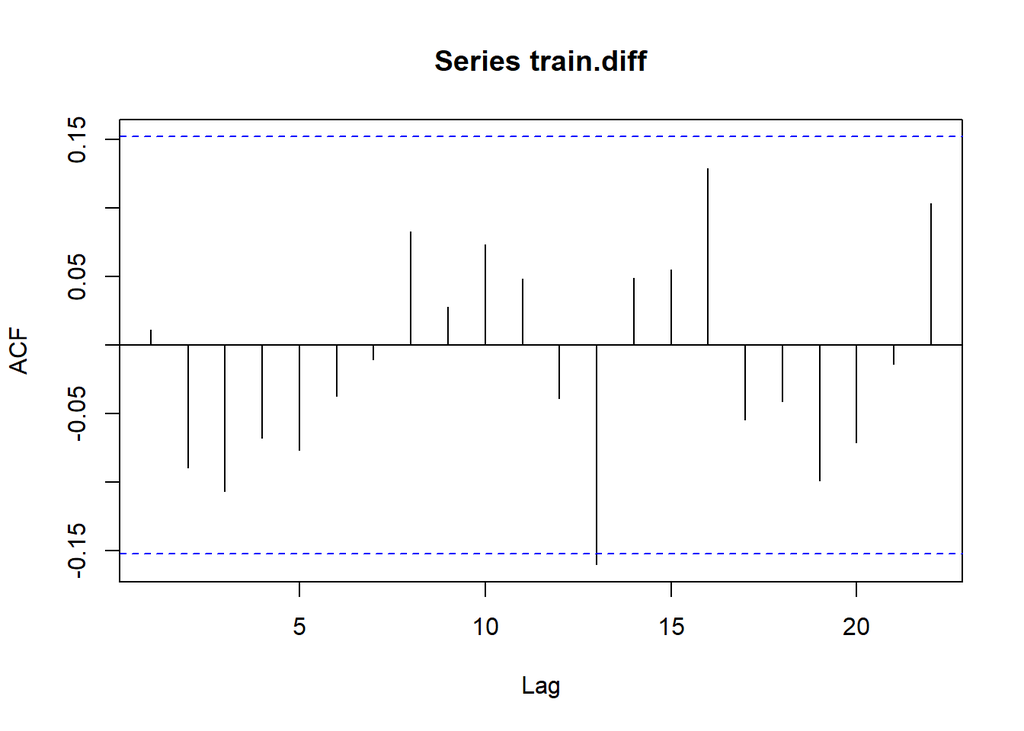

```r
acf(train.diff)
```

## Plot PACF

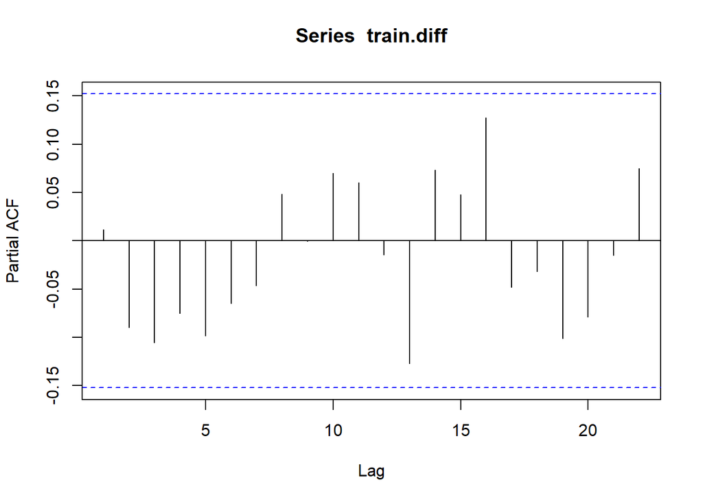

```r
pacf(train.diff)
```

## Plot EACF

```r
eacf(train.diff)
```

```
## AR/MA
##   0 1 2 3 4 5 6 7 8 9 10 11 12 13
## 0 o o o o o o o o o o o  o  o  o
## 1 o o o o o o o o o o o  o  x  o
## 2 x x o o o o o o o o o  o  o  o
## 3 x x o o o o o o o o o  o  o  o
## 4 x x x o o o o o o o o  o  o  o
## 5 x o x x x o o o o o o  o  o  o
## 6 x o x o x o o o o o o  o  o  o
## 7 x x x o x x o o o o o  o  o  o
```

Baik ACF maupun PACF pada $\Delta Y_t$ tampak datar, dengan hampir seluruh lag berada di dalam batas signifikansi ±0.15 dan tanpa pola *cut‑off* yang tajam. Kemiripan kedua plot ini menandakan deret differencing sudah mendekati *white noise*. Tabel EACF memperkuat temuan tersebut, yaitu tidak terbentuk blok “x” yang rapi pada orde rendah, melainkan sebaran “x” acak di sudut kiri‑bawah yang merupakan *noise floor*, disertai satu titik “x” terisolasi pada sel (p = 1, q = 12) yang merupakan outlier. Konsekuensinya, tidak ada ordo AR/MA menengah‑tinggi yang didukung data. Model tentatif ARIMA yang terbentuk dan akan ditinjau, antara lain, ARIMA(0,1,0), ARIMA(1,1,0), ARIMA(0,1,1), ARIMA(1,1,1), ARIMA(0,1,2), ARIMA(1,1,2), ARIMA(2,1,2), dan ARIMA(0,1,3)

# Pendugaan Parameter Model Tentatif

## ARIMA(0,1,0)

```r
model1.da=Arima(train.ts, order=c(0,1,0), method="ML")
summary(model1.da)
```

```
## Series: train.ts
## ARIMA(0,1,0)
##
## sigma^2 = 273.1:  log likelihood = -701.17
## AIC=1404.34   AICc=1404.36   BIC=1407.45
##
## Training set error measures:
##                     ME     RMSE      MAE         MPE      MAPE      MASE
## Training set 0.1939106 16.47742 12.49164 0.007790823 0.9639753 0.9945903
##                    ACF1
## Training set 0.01184344
```

## ARIMA(1,1,0)

```r
model2.da=Arima(train.ts, order=c(1,1,0),method="ML")
summary(model2.da)
```

```
## Series: train.ts
## ARIMA(1,1,0)
##
## Coefficients:
##          ar1
##       0.0116
## s.e.  0.0784
##
## sigma^2 = 274.8:  log likelihood = -701.16
## AIC=1406.32   AICc=1406.39   BIC=1412.54
##
## Training set error measures:
##                     ME     RMSE      MAE         MPE      MAPE     MASE
## Training set 0.1901838 16.47632 12.50077 0.007582673 0.9647824 0.995318
##                     ACF1
## Training set 0.001403377
```

```r
lmtest::coeftest(model2.da)
```

```
##
## z test of coefficients:
##
##     Estimate Std. Error z value Pr(>|z|)
## ar1 0.011614   0.078366  0.1482   0.8822
```

## ARIMA(0,1,1)

```r
model3.da=Arima(train.ts, order=c(0,1,1),method="ML")
summary(model3.da)
```

```
## Series: train.ts
## ARIMA(0,1,1)
##
## Coefficients:
##          ma1
##       0.0141
## s.e.  0.0863
##
## sigma^2 = 274.8:  log likelihood = -701.16
## AIC=1406.31   AICc=1406.39   BIC=1412.54
##
## Training set error measures:
##                     ME     RMSE      MAE         MPE      MAPE      MASE
## Training set 0.1894115 16.47608 12.50267 0.007539192 0.9649506 0.9954692
##                       ACF1
## Training set -0.0008851302
```

```r
lmtest::coeftest(model3.da)
```

```
##
## z test of coefficients:
##
##     Estimate Std. Error z value Pr(>|z|)
## ma1 0.014139   0.086255  0.1639   0.8698
```

## ARIMA(1,1,1)

```r
model4.da=Arima(train.ts, order=c(1,1,1),method="ML")
summary(model4.da)
```

```
## Series: train.ts
## ARIMA(1,1,1)
##
## Coefficients:
##           ar1    ma1
##       -0.3942  0.423
## s.e.   0.8860  0.870
##
## sigma^2 = 276.2:  log likelihood = -701.09
## AIC=1408.18   AICc=1408.33   BIC=1417.52
##
## Training set error measures:
##                     ME     RMSE      MAE         MPE      MAPE      MASE
## Training set 0.1864244 16.46951 12.49784 0.007355126 0.9647431 0.9950846
##                     ACF1
## Training set -0.01501932
```

```r
lmtest::coeftest(model4.da)
```

```
##
## z test of coefficients:
##
##     Estimate Std. Error z value Pr(>|z|)
## ar1 -0.39423    0.88601 -0.4449   0.6564
## ma1  0.42303    0.87004  0.4862   0.6268
```

## ARIMA(0,1,2)

```r
model5.da=Arima(train.ts, order=c(0,1,2),method="ML")
summary(model5.da)
```

```
## Series: train.ts
## ARIMA(0,1,2)
##
## Coefficients:
##           ma1      ma2
##       -0.0146  -0.1130
## s.e.   0.0819   0.0885
##
## sigma^2 = 273.7:  log likelihood = -700.35
## AIC=1406.69   AICc=1406.84   BIC=1416.03
##
## Training set error measures:
##                     ME     RMSE      MAE         MPE      MAPE      MASE
## Training set 0.2235837 16.39464 12.46373 0.009263655 0.9614758 0.9923688
##                   ACF1
## Training set 0.0143015
```

```r
lmtest::coeftest(model5.da)
```

```
##
## z test of coefficients:
##
##      Estimate Std. Error z value Pr(>|z|)
## ma1 -0.014615   0.081875 -0.1785   0.8583
## ma2 -0.112954   0.088511 -1.2762   0.2019
```

## ARIMA(1,1,2)

```r
model6.da=Arima(train.ts, order=c(1,1,2),method="ML")
summary(model6.da)
```

```
## Series: train.ts
## ARIMA(1,1,2)
##
## Coefficients:
##          ar1      ma1      ma2
##       0.5791  -0.5966  -0.1236
## s.e.  0.2048   0.2078   0.0821
##
## sigma^2 = 270.1:  log likelihood = -698.77
## AIC=1405.55   AICc=1405.8   BIC=1418
##
## Training set error measures:
##                     ME     RMSE      MAE        MPE      MAPE      MASE
## Training set 0.2977172 16.23723 12.41594 0.01389617 0.9574298 0.9885635
##                     ACF1
## Training set 0.004718243
```

```r
lmtest::coeftest(model6.da)
```

```
##
## z test of coefficients:
##
##      Estimate Std. Error z value Pr(>|z|)
## ar1  0.579051   0.204797  2.8274 0.004692 **
## ma1 -0.596589   0.207849 -2.8703 0.004101 **
## ma2 -0.123588   0.082075 -1.5058 0.132121
## ---
## Signif. codes:  0 '***' 0.001 '**' 0.01 '*' 0.05 '.' 0.1 ' ' 1
```

## ARIMA(2,1,2)

```r
model7.da=Arima(train.ts, order=c(2,1,2),method="ML")
summary(model7.da)
```

```
## Series: train.ts
## ARIMA(2,1,2)
##
## Coefficients:
##          ar1      ar2      ma1    ma2
##       1.5533  -0.8230  -1.5961  0.800
## s.e.  0.2099   0.2074   0.2100  0.235
##
## sigma^2 = 267.6:  log likelihood = -697.58
## AIC=1405.15   AICc=1405.53   BIC=1420.71
##
## Training set error measures:
##                     ME     RMSE      MAE         MPE      MAPE      MASE
## Training set 0.2282965 16.11213 12.22339 0.009128098 0.9427104 0.9732322
##                    ACF1
## Training set 0.01796559
```

```r
lmtest::coeftest(model7.da)
```

```
##
## z test of coefficients:
##
##     Estimate Std. Error z value  Pr(>|z|)
## ar1  1.55334    0.20986  7.4016 1.345e-13 ***
## ar2 -0.82297    0.20741 -3.9679 7.250e-05 ***
## ma1 -1.59608    0.20995 -7.6021 2.914e-14 ***
## ma2  0.80005    0.23501  3.4043 0.0006633 ***
## ---
## Signif. codes:  0 '***' 0.001 '**' 0.01 '*' 0.05 '.' 0.1 ' ' 1
```

## ARIMA(0,1,3)

```r
model8.da=Arima(train.ts, order=c(0,1,3),method="ML")
summary(model8.da)
```

```
## Series: train.ts
## ARIMA(0,1,3)
##
## Coefficients:
##           ma1      ma2      ma3
##       -0.0202  -0.1276  -0.1311
## s.e.   0.0782   0.0832   0.0765
##
## sigma^2 = 270.7:  log likelihood = -698.94
## AIC=1405.89   AICc=1406.14   BIC=1418.34
##
## Training set error measures:
##                     ME     RMSE      MAE        MPE     MAPE      MASE
## Training set 0.2633896 16.25356 12.44869 0.01146522 0.959507 0.9911713
##                     ACF1
## Training set 0.008992135
```

```r
lmtest::coeftest(model8.da)
```

```
##
## z test of coefficients:
##
##      Estimate Std. Error z value Pr(>|z|)
## ma1 -0.020181   0.078237 -0.2579  0.79645
## ma2 -0.127642   0.083181 -1.5345  0.12490
## ma3 -0.131073   0.076494 -1.7135  0.08662 .
## ---
## Signif. codes:  0 '***' 0.001 '**' 0.01 '*' 0.05 '.' 0.1 ' ' 1
```

# Ringkasan AIC

```r
model_tentatif <- data.frame(
  Model = c("ARIMA(0,1,0)","ARIMA(1,1,0)","ARIMA(0,1,1)", "ARIMA(1,1,1)", "ARIMA(0,1,2)", "ARIMA(1,1,2)", "ARIMA(2,1,2)", "ARIMA(0,1,3)"),
  AIC   = c(AIC(model1.da),AIC(model2.da), AIC(model3.da), AIC(model4.da), AIC(model5.da), AIC(model6.da), AIC(model7.da), AIC(model8.da)),
  BIC   = c(BIC(model1.da),BIC(model2.da), BIC(model3.da), BIC(model4.da), BIC(model5.da), BIC(model6.da), BIC(model7.da), BIC(model8.da))
)

model_tentatif
```

```
##          Model      AIC      BIC
## 1 ARIMA(0,1,0) 1404.340 1407.452
## 2 ARIMA(1,1,0) 1406.318 1412.542
## 3 ARIMA(0,1,1) 1406.313 1412.537
## 4 ARIMA(1,1,1) 1408.182 1417.518
## 5 ARIMA(0,1,2) 1406.694 1416.030
## 6 ARIMA(1,1,2) 1405.548 1417.996
## 7 ARIMA(2,1,2) 1405.153 1420.713
## 8 ARIMA(0,1,3) 1405.888 1418.336
```

# Analisis Sisaan

## Eksplorasi Sisaan

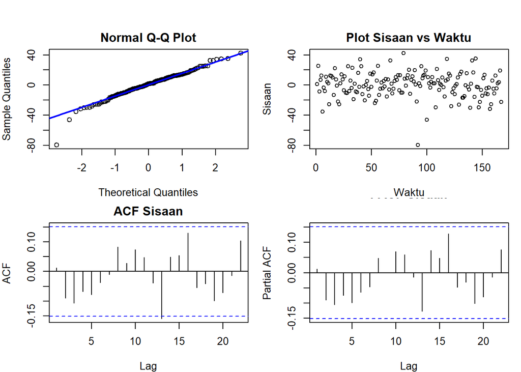

```r
sisaan.da <- model1.da$residuals

par(mfrow = c(2,2),
    mar = c(4,4,2,1),
    oma = c(0,0,2,0))

qqnorm(sisaan.da, main = "Normal Q-Q Plot")
qqline(sisaan.da, col = "blue", lwd = 2)

plot(sisaan.da, type = "p",
     main = "Plot Sisaan vs Waktu",
     xlab = "Waktu", ylab = "Sisaan")

acf(sisaan.da, main = "ACF Sisaan")

pacf(sisaan.da, main = "PACF Sisaan")
```

## Uji Formal

### Sisaan Menyebar Normal

```r
shapiro.test(sisaan.da)
```

```
##
##  Shapiro-Wilk normality test
##
## data:  sisaan.da
## W = 0.96743, p-value = 0.0005818
```

$H_0$ : Sisaan menyebar normal

$H_1$ : Sisaan tidak menyebar normal

Berdasarkan uji Shapiro-Wilk, didapat *p-value* sebesar 0.00058 yang kurang dari taraf nyata 5% sehingga tolak $H_0$ dan menandakan bahwa sisaan tidak menyebar normal.

### Sisaan Saling Bebas

```r
Box.test(sisaan.da, type = "Ljung")
```

```
##
##  Box-Ljung test
##
## data:  sisaan.da
## X-squared = 0.023848, df = 1, p-value = 0.8773
```

$H_0$ : Sisaan saling bebas

$H_1$ : Sisaan tidak tidak saling bebas

Berdasarkan uji Ljung-Box, didapat *p-value* sebesar 0.8773 yang lebih besar dari taraf nyata 5% sehingga gagal tolak $H_0$ dan menandakan sisaan saling bebas.

### Sisaan Homogen

```r
Box.test((sisaan.da)^2, type = "Ljung")
```

```
##
##  Box-Ljung test
##
## data:  (sisaan.da)^2
## X-squared = 0.066672, df = 1, p-value = 0.7962
```

$H_0$ : Ragam sisaan homogen

$H_1$ : Ragam sisaan tidak homogen

Berdasarkan uji Ljung-Box terhadap sisaan kuadrat tersebut, didapat *p-value* sebesar 0.7962 yang lebih besar dari taraf nyata 5% sehingga gagal tolak $H_0$ dan menandakan bahwa ragam sisaan homogen.

### Nilai Tengah Sisaan Sama dengan Nol

```r
t.test(sisaan.da, mu = 0, conf.level = 0.95)
```

```
##
##  One Sample t-test
##
## data:  sisaan.da
## t = 0.15163, df = 166, p-value = 0.8797
## alternative hypothesis: true mean is not equal to 0
## 95 percent confidence interval:
##  -2.330912  2.718733
## sample estimates:
## mean of x
## 0.1939106
```

$H_0$ : Nilai tengah sisaan sama dengan nol

$H_1$ : Nilai tengah sisaan tidak sama dengan nol

Berdasarkan uji t, didapat *p-value* sebesar 0.8797 yang lebih besar dari taraf nyata 5% sehingga tak tolak $H_0$ dan menandakan bahwa nilai tengah sisaan sama dengan nol.

# Overfitting

Tahapan selanjutnya adalah *overfitting* yang dilakukan dengan menaikkan orde AR(p) dan MA(q) dari model ARIMA(0,1,0). Kandidat model *overfitting* adalah ARIMA(1,1,0) dan ARIMA(0,1,1). Namun, karena model hasil overfitting sudah termasuk di dalam model tentatif dan hasilnya tidak lebih baik, model terbaik yang dipilih adalah ARIMA(0,1,0).

# Model Terbaik

```r
summary(model1.da)
```

```
## Series: train.ts
## ARIMA(0,1,0)
##
## sigma^2 = 273.1:  log likelihood = -701.17
## AIC=1404.34   AICc=1404.36   BIC=1407.45
##
## Training set error measures:
##                     ME     RMSE      MAE         MPE      MAPE      MASE
## Training set 0.1939106 16.47742 12.49164 0.007790823 0.9639753 0.9945903
##                    ACF1
## Training set 0.01184344
```

Parameter yang diestimasi adalah varians error, yaitu $\sigma^2$ = 273.1 dengan standar deviasi error $\sigma$ = 16.53.

# Peramalan

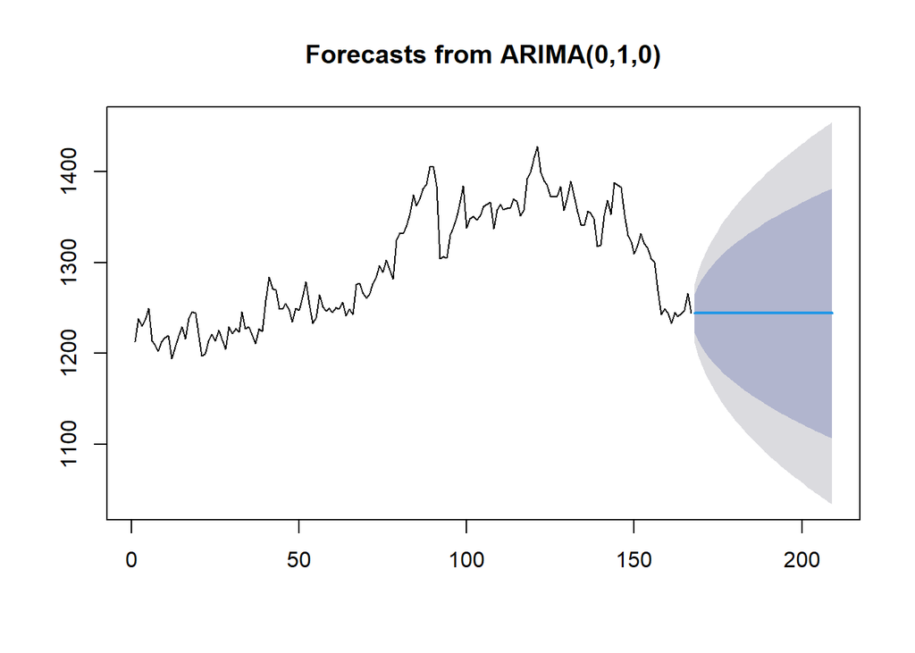

```r
ramalan.da <- forecast::forecast(model1.da, h = length(test.ts))
data.ramalan.da <- ramalan.da$mean
plot(ramalan.da)
```

```r
ramalan.da<-forecast::forecast(model1.da, h = length(test.ts))
hasil<-as.numeric(ramalan.da$mean)

perbandingan.da<-cbind(Aktual = as.numeric(test.ts), Forecast = hasil)
print(head(perbandingan.da, 10))
```

```
##        Aktual Forecast
##  [1,] 1240.02  1244.24
##  [2,] 1228.08  1244.24
##  [3,] 1241.95  1244.24
##  [4,] 1254.12  1244.24
##  [5,] 1272.20  1244.24
##  [6,] 1275.70  1244.24
##  [7,] 1250.79  1244.24
##  [8,] 1257.04  1244.24
##  [9,] 1237.59  1244.24
## [10,] 1234.61  1244.24
```

```r
akurasi_test <- accuracy(hasil, test.ts)
akurasi_test
```

```
##                 ME     RMSE      MAE       MPE     MAPE
## Test set -28.04929 39.94106 32.60881 -2.362394 2.722441
```

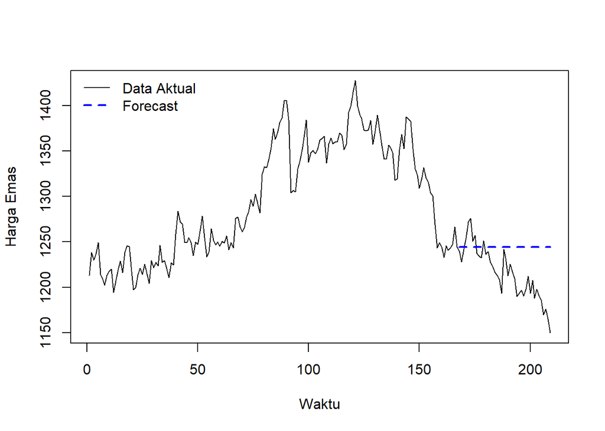

```r
ts.plot(data.ts, col = "black", lty = 1,
        xlab = "Waktu", ylab = "Harga Emas")

lines(168:(167+length(hasil)), hasil, col = "blue", lty = 2, lwd = 2)
legend("topleft",
       legend = c("Data Aktual", "Forecast"),
       col = c("black", "blue"),
       lty = c(1,2), lwd = c(1,2), bty = "n")
```